# Generalised linear mixed models with R

Concepts, partial pooling and `glmer()` syntax

O Rodriguez de Rivera Ortega, PhD

University of Exeter

# Session overview

## Learning outcomes

By the end of this section, students should be able to:

- explain why grouped or repeated observations require special care;
- distinguish complete pooling, no pooling and partial pooling;
- fit random-intercept and random-slope models using `lme4`;
- explain what random effects represent;
- recognise the difference between an LMM and a GLMM;
- write basic `glmer()` formulae for binomial and Poisson responses.

# Setup

## Packages

```r
install.packages(c("tidyverse", "lme4", "broom.mixed", "ggeffects"))
```

```r
library(tidyverse)
library(lme4)
library(ggeffects)

theme_set(theme_minimal(base_size = 12))
```

# Why mixed models?

## Grouped data are common

Examples:

- trees measured within sites;
- repeated measurements on the same individual;
- students within schools;
- animals within litters or broods;
- ecological plots within landscapes;
- patients within hospitals.

The problem: observations within the same group tend to be more similar than observations from different groups.

Ignoring that structure can lead to:

- underestimated uncertainty;
- overconfident p-values;
- misleading fixed-effect estimates;
- poor predictions for new groups.

## A mixed model separates two sources of variation

A simple random-intercept model is:

$$Y_{ij} = \beta_0 + \beta_1 x_{ij} +
b_{0j} + \varepsilon_{ij},$$

where:

- $i$ indexes observations;
- $j$ indexes groups;
- $\beta_0, \beta_1$ are fixed effects;
- $b_{0j}$ is a group-specific random intercept;
- $b_{0j} \sim N(0, \sigma^2_{group})$.

The random effect estimates how much groups vary around the population average.

# Example: sleep deprivation data

## Load the data

The `sleepstudy` dataset is included in `lme4`. It contains reaction times measured repeatedly on subjects over days of sleep deprivation.

```r
data("sleepstudy", package = "lme4")

sleepstudy <- sleepstudy %>%
  mutate(Subject = factor(Subject))

glimpse(sleepstudy)
```

```
## Rows: 180
## Columns: 3
## $ Reaction <dbl> 249.5600, 258.7047, 250.8006, 321.4398, 356.8519, 414.6901, 3…
## $ Days     <dbl> 0, 1, 2, 3, 4, 5, 6, 7, 8, 9, 0, 1, 2, 3, 4, 5, 6, 7, 8, 9, 0…
## $ Subject  <fct> 308, 308, 308, 308, 308, 308, 308, 308, 308, 308, 309, 309, 3…
```

## Explore the repeated measurements

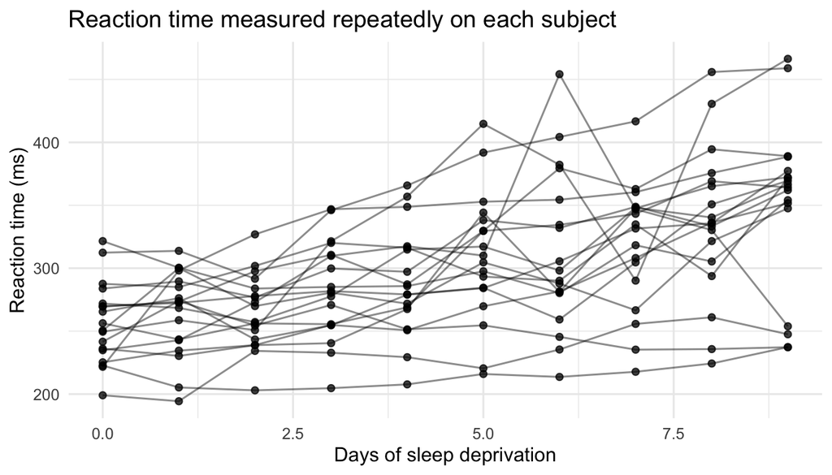

```r
ggplot(sleepstudy, aes(x = Days, y = Reaction, group = Subject)) +
  geom_line(alpha = 0.45) +
  geom_point(alpha = 0.75) +
  labs(
    title = "Reaction time measured repeatedly on each subject",
    x = "Days of sleep deprivation",
    y = "Reaction time (ms)"
  )
```

# Pooling strategies

## Complete pooling

Complete pooling ignores subject differences.

```r
lm_complete <- lm(Reaction ~ Days, data = sleepstudy)
summary(lm_complete)
```

```
##
## Call:
## lm(formula = Reaction ~ Days, data = sleepstudy)
##
## Residuals:
##      Min       1Q   Median       3Q      Max
## -110.848  -27.483    1.546   26.142  139.953
##
## Coefficients:
##             Estimate Std. Error t value Pr(>|t|)
## (Intercept)  251.405      6.610  38.033  < 2e-16 ***
## Days          10.467      1.238   8.454 9.89e-15 ***
## ---
## Signif. codes:  0 '***' 0.001 '**' 0.01 '*' 0.05 '.' 0.1 ' ' 1
##
## Residual standard error: 47.71 on 178 degrees of freedom
## Multiple R-squared:  0.2865, Adjusted R-squared:  0.2825
## F-statistic: 71.46 on 1 and 178 DF,  p-value: 9.894e-15
```

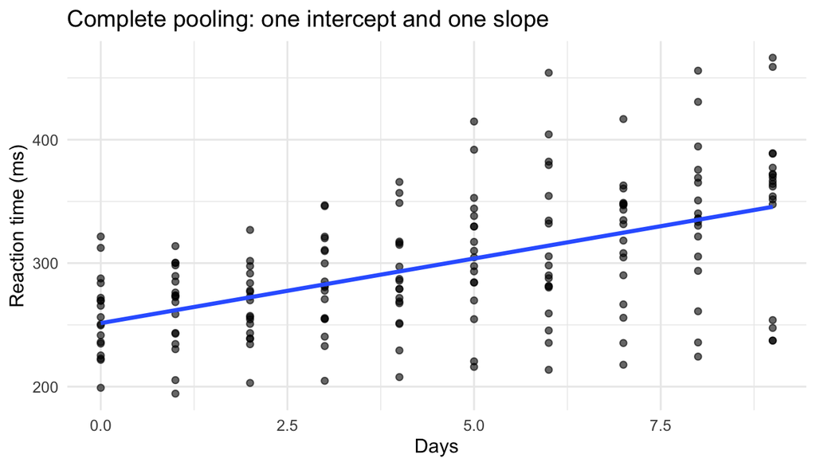

```r
ggplot(sleepstudy, aes(x = Days, y = Reaction)) +
  geom_point(alpha = 0.6) +
  geom_smooth(method = "lm", se = FALSE, linewidth = 1.2) +
  labs(
    title = "Complete pooling: one intercept and one slope",
    x = "Days",
    y = "Reaction time (ms)"
  )
```

## No pooling

No pooling estimates a separate intercept for each subject as fixed effects.

```r
lm_no_pooling <- lm(Reaction ~ Days + Subject, data = sleepstudy)
summary(lm_no_pooling)
```

```
##
## Call:
## lm(formula = Reaction ~ Days + Subject, data = sleepstudy)
##
## Residuals:
##      Min       1Q   Median       3Q      Max
## -100.540  -16.389   -0.341   15.215  131.159
##
## Coefficients:
##              Estimate Std. Error t value Pr(>|t|)
## (Intercept)  295.0310    10.4471  28.240  < 2e-16 ***
## Days          10.4673     0.8042  13.015  < 2e-16 ***
## Subject309  -126.9008    13.8597  -9.156 2.35e-16 ***
## Subject310  -111.1326    13.8597  -8.018 2.07e-13 ***
## Subject330   -38.9124    13.8597  -2.808 0.005609 **
## Subject331   -32.6978    13.8597  -2.359 0.019514 *
## Subject332   -34.8318    13.8597  -2.513 0.012949 *
## Subject333   -25.9755    13.8597  -1.874 0.062718 .
## Subject334   -46.8318    13.8597  -3.379 0.000913 ***
## Subject335   -92.0638    13.8597  -6.643 4.51e-10 ***
## Subject337    33.5872    13.8597   2.423 0.016486 *
## Subject349   -66.2994    13.8597  -4.784 3.87e-06 ***
## Subject350   -28.5312    13.8597  -2.059 0.041147 *
## Subject351   -52.0361    13.8597  -3.754 0.000242 ***
## Subject352    -4.7123    13.8597  -0.340 0.734300
## Subject369   -36.0992    13.8597  -2.605 0.010059 *
## Subject370   -50.4321    13.8597  -3.639 0.000369 ***
## Subject371   -47.1498    13.8597  -3.402 0.000844 ***
## Subject372   -24.2477    13.8597  -1.750 0.082108 .
## ---
## Signif. codes:  0 '***' 0.001 '**' 0.01 '*' 0.05 '.' 0.1 ' ' 1
##
## Residual standard error: 30.99 on 161 degrees of freedom
## Multiple R-squared:  0.7277, Adjusted R-squared:  0.6973
## F-statistic: 23.91 on 18 and 161 DF,  p-value: < 2.2e-16
```

This uses many parameters and treats each subject effect as unrelated to the others.

## Partial pooling

Partial pooling estimates subject effects as coming from a common distribution.

```r
lmm_intercept <- lmer(Reaction ~ Days + (1 | Subject), data = sleepstudy)
summary(lmm_intercept)
```

```
## Linear mixed model fit by REML ['lmerMod']
## Formula: Reaction ~ Days + (1 | Subject)
##    Data: sleepstudy
##
## REML criterion at convergence: 1786.5
##
## Scaled residuals:
##     Min      1Q  Median      3Q     Max
## -3.2257 -0.5529  0.0109  0.5188  4.2506
##
## Random effects:
##  Groups   Name        Variance Std.Dev.
##  Subject  (Intercept) 1378.2   37.12
##  Residual              960.5   30.99
## Number of obs: 180, groups:  Subject, 18
##
## Fixed effects:
##             Estimate Std. Error t value
## (Intercept) 251.4051     9.7467   25.79
## Days         10.4673     0.8042   13.02
##
## Correlation of Fixed Effects:
##      (Intr)
## Days -0.371
```

The model estimates:

- the average relationship between `Days` and `Reaction`;
- the between-subject variance in baseline reaction time;
- the residual within-subject variance.

## Compare the three approaches

```r
AIC(lm_complete, lm_no_pooling, lmm_intercept)
```

```
##               df      AIC
## lm_complete    3 1906.293
## lm_no_pooling 20 1766.872
## lmm_intercept  4 1794.465
```

AIC is not the only criterion, but it helps compare models fitted to the same response.

# Random slopes

## What if subjects differ in their slope?

A random-intercept model assumes subjects start at different baseline levels but have the same slope.

A random-slope model allows the effect of `Days` to vary by subject:

$$Y_{ij} = \beta_0 + \beta_1 x_{ij} +
b_{0j} + b_{1j}x_{ij} + \varepsilon_{ij}.$$

```r
lmm_slope <- lmer(Reaction ~ Days + (Days | Subject), data = sleepstudy)
summary(lmm_slope)
```

```
## Linear mixed model fit by REML ['lmerMod']
## Formula: Reaction ~ Days + (Days | Subject)
##    Data: sleepstudy
##
## REML criterion at convergence: 1743.6
##
## Scaled residuals:
##     Min      1Q  Median      3Q     Max
## -3.9536 -0.4634  0.0231  0.4634  5.1793
##
## Random effects:
##  Groups   Name        Variance Std.Dev. Corr
##  Subject  (Intercept) 612.10   24.741
##           Days         35.07    5.922   0.07
##  Residual             654.94   25.592
## Number of obs: 180, groups:  Subject, 18
##
## Fixed effects:
##             Estimate Std. Error t value
## (Intercept)  251.405      6.825  36.838
## Days          10.467      1.546   6.771
##
## Correlation of Fixed Effects:
##      (Intr)
## Days -0.138
```

## Visualise subject-specific fitted lines

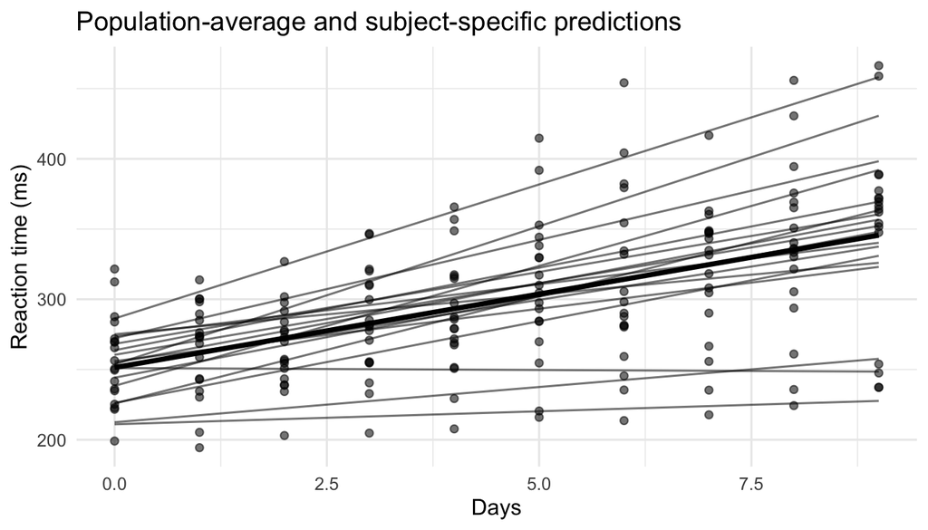

```r
sleep_pred <- sleepstudy %>%
  mutate(
    population_prediction = predict(lmm_slope, re.form = NA),
    subject_prediction = predict(lmm_slope)
  )

ggplot(sleep_pred, aes(x = Days, y = Reaction, group = Subject)) +
  geom_point(alpha = 0.55) +
  geom_line(aes(y = subject_prediction), alpha = 0.55) +
  geom_line(aes(y = population_prediction, group = 1), linewidth = 1.3) +
  labs(
    title = "Population-average and subject-specific predictions",
    x = "Days",
    y = "Reaction time (ms)"
  )
```

## Random effects and shrinkage

```r
ranef(lmm_slope)$Subject %>%
  as.data.frame() %>%
  rownames_to_column("Subject") %>%
  rename(
    intercept_deviation = `(Intercept)`,
    slope_deviation = Days
  ) %>%
  arrange(desc(slope_deviation)) %>%
  head()
```

```
##   Subject intercept_deviation slope_deviation
## 1     308            2.258551        9.198976
## 2     337           34.890487        8.628265
## 3     350          -13.070034        6.614218
## 4     370          -25.612999        4.822485
## 5     352           20.863678        3.536001
## 6     372           12.314592        1.284022
```

Random effects are **deviations from the population average**. They are not estimated independently for each group; they are pulled towards the overall mean, especially for groups with little information.

## Practical model syntax

```r
# Random intercept
lmer(y ~ x + (1 | group), data = my_data)

# Random intercept and random slope
lmer(y ~ x + (x | group), data = my_data)

# Random intercept and random slope, no covariance
lmer(y ~ x + (1 | group) + (0 + x | group), data = my_data)

# Nested random effects
lmer(y ~ x + (1 | site/plot), data = my_data)

# Crossed random effects
lmer(y ~ x + (1 | site) + (1 | observer), data = my_data)
```

# From LMMs to GLMMs

## What changes in a GLMM?

A GLMM keeps the random-effect structure but changes the response distribution and link.

For a binomial GLMM:

$$Y_{ij} \sim Binomial(n_{ij},
p_{ij})$$

$$logit(p_{ij}) = \beta_0 + \beta_1 x_{ij}
+ b_{0j}.$$

For a Poisson GLMM:

$$Y_{ij} \sim
Poisson(\mu_{ij})$$

$$log(\mu_{ij}) = \beta_0 + \beta_1 x_{ij}
+ b_{0j}.$$

## `glmer()` syntax

```r
# Binary response
glmer(presence ~ habitat + (1 | site),
      family = binomial,
      data = my_data)

# Grouped binomial response
glmer(cbind(successes, failures) ~ treatment + (1 | group),
      family = binomial,
      data = my_data)

# Count response
glmer(count ~ treatment + (1 | site),
      family = poisson,
      data = my_data)
```

# Short GLMM example

## Disease incidence in herds

The `cbpp` dataset is included in `lme4`. Each row is a herd-period combination, with the number of new disease cases and the herd size.

```r
data("cbpp", package = "lme4")

cbpp <- cbpp %>%
  mutate(
    herd = factor(herd),
    period = factor(period),
    failures = size - incidence,
    proportion = incidence / size
  )

glimpse(cbpp)
```

```
## Rows: 56
## Columns: 6
## $ herd       <fct> 1, 1, 1, 1, 2, 2, 2, 3, 3, 3, 3, 4, 4, 4, 4, 5, 5, 5, 5, 6,…
## $ incidence  <dbl> 2, 3, 4, 0, 3, 1, 1, 8, 2, 0, 2, 2, 0, 2, 0, 5, 0, 0, 1, 3,…
## $ size       <dbl> 14, 12, 9, 5, 22, 18, 21, 22, 16, 16, 20, 10, 10, 9, 6, 18,…
## $ period     <fct> 1, 2, 3, 4, 1, 2, 3, 1, 2, 3, 4, 1, 2, 3, 4, 1, 2, 3, 4, 1,…
## $ failures   <dbl> 12, 9, 5, 5, 19, 17, 20, 14, 14, 16, 18, 8, 10, 7, 6, 13, 2…
## $ proportion <dbl> 0.14285714, 0.25000000, 0.44444444, 0.00000000, 0.13636364,…
```

## Plot the grouped binomial response

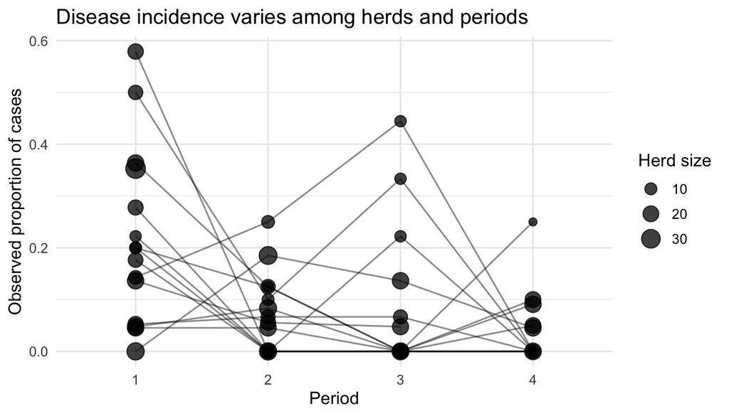

```r
ggplot(cbpp, aes(x = period, y = proportion, group = herd)) +
  geom_line(alpha = 0.45) +
  geom_point(aes(size = size), alpha = 0.75) +
  labs(
    title = "Disease incidence varies among herds and periods",
    x = "Period",
    y = "Observed proportion of cases",
    size = "Herd size"
  )
```

## Fit a binomial GLMM

```r
cbpp_glmm <- glmer(
  cbind(incidence, failures) ~ period + (1 | herd),
  family = binomial,
  data = cbpp
)

summary(cbpp_glmm)
```

```
## Generalized linear mixed model fit by maximum likelihood (Laplace
##   Approximation) [glmerMod]
##  Family: binomial  ( logit )
## Formula: cbind(incidence, failures) ~ period + (1 | herd)
##    Data: cbpp
##
##       AIC       BIC    logLik -2*log(L)  df.resid
##     194.1     204.2     -92.0     184.1        51
##
## Scaled residuals:
##     Min      1Q  Median      3Q     Max
## -2.3816 -0.7889 -0.2026  0.5142  2.8791
##
## Random effects:
##  Groups Name        Variance Std.Dev.
##  herd   (Intercept) 0.4123   0.6421
## Number of obs: 56, groups:  herd, 15
##
## Fixed effects:
##             Estimate Std. Error z value Pr(>|z|)
## (Intercept)  -1.3983     0.2312  -6.048 1.47e-09 ***
## period2      -0.9919     0.3032  -3.272 0.001068 **
## period3      -1.1282     0.3228  -3.495 0.000474 ***
## period4      -1.5797     0.4220  -3.743 0.000182 ***
## ---
## Signif. codes:  0 '***' 0.001 '**' 0.01 '*' 0.05 '.' 0.1 ' ' 1
##
## Correlation of Fixed Effects:
##         (Intr) perid2 perid3
## period2 -0.363
## period3 -0.340  0.280
## period4 -0.260  0.213  0.198
```

## Interpret the fixed effects

The fixed effects are on the log-odds scale. Exponentiating gives odds ratios.

```r
exp(fixef(cbpp_glmm))
```

```
## (Intercept)     period2     period3     period4
##   0.2470059   0.3708621   0.3236100   0.2060275
```

## Predict probabilities

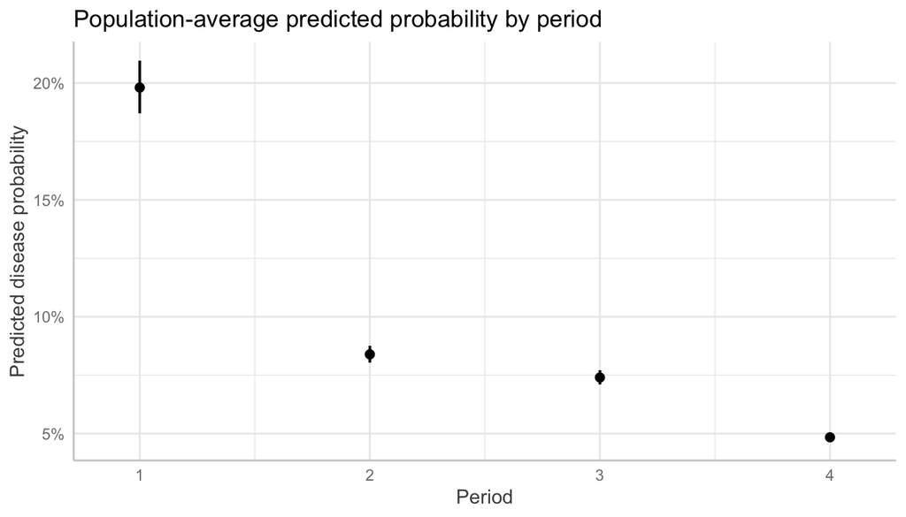

```r
period_predictions <- ggpredict(cbpp_glmm, terms = "period", type = "fixed")

plot(period_predictions) +
  labs(
    title = "Population-average predicted probability by period",
    x = "Period",
    y = "Predicted disease probability"
  )
```

# Exercise

## Short exercise: choosing the random-effect structure

For each study design, suggest a model formula.

1. Seedling survival measured in plots nested within forests.
2. Number of bird calls recorded at repeated visits to sites.
3. Infection status of plants sampled from different fields.
4. Biomass measured repeatedly from the same experimental tanks.

Use this template:

```r
glmer(response ~ fixed_effects + (1 | grouping_variable),
      family = ..., data = ...)
```

## Key points

- Random effects model dependence among observations within the same group.
- Fixed effects estimate population-average relationships.
- Random effects estimate between-group variability.
- GLMMs combine random effects with non-Gaussian response distributions.
- Model interpretation must distinguish the link scale from the response scale.